# Differential expression analysis for 2024_10 release NW_RNAseq_1

Si Liu, Wei Sun

2024-12-13

Differential expression analysis using the bulk RNAseq NW_RNAseq_1 data from the October 2024 release.

This dataset involves three treatment settings:

```
DMSO
Auxin_6h
Auxin_24h
```

## R libraries.

```r
library(ggplot2)
library(ggrepel)
library(ggpubr)
library(stringr)
library(MASS)
library(RColorBrewer)
library(DESeq2)

library(viridis)
library(ggpointdensity)
library(dplyr)
library(data.table)
library(ComplexHeatmap)
library(UpSetR)
library(readxl)
theme_set(theme_classic())

path = "../../MorPhiC/data/October-2024/NW_RNAseq_1"
dat_path = file.path(path, "processed/release110-gencode44/Tables")
```

## Read in meta data

```r
meta = fread("data/October_2024/NW_RNAseq_1_meta_data.tsv",
             data.table = FALSE)
dim(meta)
```

```
## [1] 12 16
```

```r
meta[1:2,]
```

```
##         clonal_label        lib_label   undifferentiated_product.label
## 1 ADLI00042105_RBBP4 23247FL-01-03-01 ADLI00042105_RBBP4_Auxin_0h_rep1
## 2 ADLI00042105_RBBP4 23247FL-01-03-02 ADLI00042105_RBBP4_Auxin_0h_rep2
##                 description timepoint_value timepoint_unit treatment_condition
## 1 RBBP4_C-terminal_AID_DMSO              24          hours                DMSO
## 2 RBBP4_C-terminal_AID_DMSO              24          hours                DMSO
##   treatment library_preparation.library_preparation_protocol_id
## 1      DMSO                  BULK_RNA_SEQ_LIBRARY_PREP_PROTOCOL
## 2      DMSO                  BULK_RNA_SEQ_LIBRARY_PREP_PROTOCOL
##                    file_id   clonal_description clonal_parental_cell_line_name
## 1 23247FL-01-03-01_S1_L005 RBBP4_C-terminal_AID                        OCM_108
## 2 23247FL-01-03-02_S2_L005 RBBP4_C-terminal_AID                        OCM_108
##     clonal_clone_id clonal_type clonal_zygosity expression_alteration.label
## 1 ADLI-0-0-042-1-05        iPSC      homozygous                NW_AID_RBBP4
## 2 ADLI-0-0-042-1-05        iPSC      homozygous                NW_AID_RBBP4
```

```r
names(meta)
```

```
##  [1] "clonal_label"
##  [2] "lib_label"
##  [3] "undifferentiated_product.label"
##  [4] "description"
##  [5] "timepoint_value"
##  [6] "timepoint_unit"
##  [7] "treatment_condition"
##  [8] "treatment"
##  [9] "library_preparation.library_preparation_protocol_id"
## [10] "file_id"
## [11] "clonal_description"
## [12] "clonal_parental_cell_line_name"
## [13] "clonal_clone_id"
## [14] "clonal_type"
## [15] "clonal_zygosity"
## [16] "expression_alteration.label"
```

```r
meta$file_id
```

```
##  [1] "23247FL-01-03-01_S1_L005"  "23247FL-01-03-02_S2_L005"
##  [3] "23247FL-01-03-03_S3_L005"  "23247FL-01-03-04_S4_L005"
##  [5] "23247FL-01-03-05_S5_L005"  "23247FL-01-03-06_S6_L005"
##  [7] "23247FL-01-03-07_S7_L005"  "23247FL-01-03-08_S8_L005"
##  [9] "23247FL-01-03-09_S9_L005"  "23247FL-01-03-10_S10_L005"
## [11] "23247FL-01-03-11_S11_L005" "23247FL-01-03-12_S12_L005"
```

## Extract knockout gene

```r
meta$ko_gene = sub("^[^_]*_([^_]*)_.*", "\\1", meta$undifferentiated_product.label)

table(meta$ko_gene, meta$expression_alteration.label)
```

```
##
##         NW_AID_CHD1 NW_AID_RBBP4
##   CHD1            6            0
##   RBBP4           0            6
```

```r
table(meta$ko_gene, meta$treatment)
```

```
##
##         Auxin_24h Auxin_6h DMSO
##   CHD1          2        2    2
##   RBBP4         2        2    2
```

```r
table(meta$ko_gene, meta$treatment_condition)
```

```
##
##         Auxin DMSO
##   CHD1      4    2
##   RBBP4     4    2
```

```r
table(meta$ko_gene, meta$clonal_parental_cell_line_name)
```

```
##
##         OCM_108 OCP74G
##   CHD1        0      6
##   RBBP4       6      0
```

## Read in gene count data

```r
cts = fread(file.path(dat_path, "genesCounts.csv"), data.table = FALSE)
dim(cts)
```

```
## [1] 38592    13
```

```r
cts[1:2, c(1:2, (ncol(cts)-1):ncol(cts))]
```

```
##              Name 23247FL-01-03-10_S10_L005 23247FL-01-03-05_S5_L005
## 1 ENSG00000268674                         0                        0
## 2 ENSG00000271254                      1319                     1967
##   23247FL-01-03-06_S6_L005
## 1                        1
## 2                     1582
```

```r
stopifnot(setequal(names(cts)[-1], meta$file_id))

meta = meta[match(names(cts)[-1], meta$file_id),]
table(names(cts)[-1] == meta$file_id, useNA="ifany")
```

```
##
## TRUE
##   12
```

```r
cts_dat = data.matrix(cts[,-1])
rownames(cts_dat) = cts$Name

table(meta$treatment, meta$treatment_condition)
```

```
##
##             Auxin DMSO
##   Auxin_24h     4    0
##   Auxin_6h      4    0
##   DMSO          0    4
```

```r
table(meta$treatment, meta$clonal_parental_cell_line_name)
```

```
##
##             OCM_108 OCP74G
##   Auxin_24h       2      2
##   Auxin_6h        2      2
##   DMSO            2      2
```

```r
table(meta$treatment, meta$clonal_clone_id)
```

```
##
##             ADLI-0-0-042-1-05 ADLI-4-0-062-1-11
##   Auxin_24h                 2                 2
##   Auxin_6h                  2                 2
##   DMSO                      2                 2
```

### Read in gene annoation

```r
gene_anno = fread("data/gencode_v44_primary_assembly_info.tsv")
dim(gene_anno)
```

```
## [1] 62754     8
```

```r
gene_anno[1:2,]
```

```
##                geneId    chr strand     start       end ensembl_gene_id
##                <char> <char> <char>     <int>     <int>          <char>
## 1: ENSG00000000003.16   chrX      - 100627108 100639991 ENSG00000000003
## 2:  ENSG00000000005.6   chrX      + 100584936 100599885 ENSG00000000005
##    hgnc_symbol                                       description
##         <char>                                            <char>
## 1:      TSPAN6 tetraspanin 6 [Source:HGNC Symbol;Acc:HGNC:11858]
## 2:        TNMD   tenomodulin [Source:HGNC Symbol;Acc:HGNC:17757]
```

```r
table(rownames(cts_dat) %in% gene_anno$ensembl_gene_id)
```

```
##
##  TRUE
## 38592
```

```r
# all ensembl gene IDs are contained in the annotation
setdiff(rownames(cts_dat), gene_anno$ensembl_gene_id)
```

```
## character(0)
```

### Discard genes whose expression is 0 in more than 75% of samples

```r
get_q75 <- function(x){quantile(x, probs = 0.75)}

gene_info = data.frame(Name = cts$Name,
                       apply(cts_dat, 1, min),
                       apply(cts_dat, 1, median),
                       apply(cts_dat, 1, get_q75),
                       apply(cts_dat, 1, max))

dim(gene_info)
```

```
## [1] 38592     5
```

```r
gene_info[1:2, ]
```

```
##                            Name apply.cts_dat..1..min.
## ENSG00000268674 ENSG00000268674                      0
## ENSG00000271254 ENSG00000271254                   1148
##                 apply.cts_dat..1..median. apply.cts_dat..1..get_q75.
## ENSG00000268674                       0.0                       0.00
## ENSG00000271254                    1443.5                    1712.75
##                 apply.cts_dat..1..max.
## ENSG00000268674                      1
## ENSG00000271254                   2452
```

```r
table(row.names(gene_info)==gene_info$Name, useNA="ifany")
```

```
##
##  TRUE
## 38592
```

```r
names(gene_info)[2:5] = rep(c("min", "median", "q75", "max"), each=1)
dim(gene_info)
```

```
## [1] 38592     5
```

```r
gene_info[1:2,]
```

```
##                            Name  min median     q75  max
## ENSG00000268674 ENSG00000268674    0    0.0    0.00    1
## ENSG00000271254 ENSG00000271254 1148 1443.5 1712.75 2452
```

```r
summary(gene_info[,-1])
```

```
##       min              median               q75                 max
##  Min.   :      0   Min.   :      0.0   Min.   :      0.0   Min.   :      0
##  1st Qu.:      0   1st Qu.:      0.0   1st Qu.:      0.0   1st Qu.:      1
##  Median :      2   Median :      7.5   Median :     11.2   Median :     19
##  Mean   :   1719   Mean   :   2516.0   Mean   :   2902.6   Mean   :   3413
##  3rd Qu.:    738   3rd Qu.:   1209.5   3rd Qu.:   1433.6   3rd Qu.:   1746
##  Max.   :1127530   Max.   :1502450.0   Max.   :1654562.5   Max.   :1912490
```

```r
table(gene_info$q75 > 0)
```

```
##
## FALSE  TRUE
## 11836 26756
```

```r
w2kp = which(gene_info$q75 > 0)
cts_dat = cts_dat[w2kp,]
dim(cts_dat)
```

```
## [1] 26756    12
```

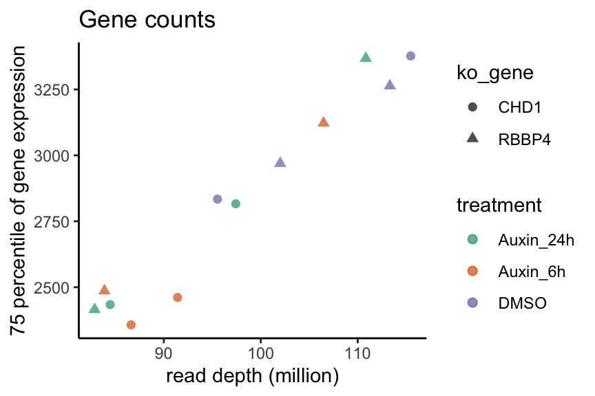

```r
gene_info = gene_info[w2kp,]

meta$read_depth = colSums(cts_dat)/1e6
meta$q75 = apply(cts_dat, 2, quantile, probs = 0.75)

ggplot(meta, aes(x=read_depth, y=q75, color=treatment, shape = ko_gene)) +
    geom_point(size=2, alpha=0.7) + ggtitle("Gene counts") +
  #scale_shape_manual(values = c(7, 16)) +
  xlab("read depth (million)") + ylab("75 percentile of gene expression") +
  labs(color = "treatment", shape = "ko_gene") +
  scale_color_brewer(palette = "Dark2")
```

## Generate PC plot

```r
summary(meta$q75)
```

```
##    Min. 1st Qu.  Median    Mean 3rd Qu.    Max.
##    2357    2454    2825    2825    3158    3377
```

```r
dim(cts_dat)
```

```
## [1] 26756    12
```

```r
stopifnot(all(meta$file_id == colnames(cts_dat)))
table(meta$file_id == colnames(cts_dat), useNA="ifany")
```

```
##
## TRUE
##   12
```

```r
cts_dat_n = t(cts_dat)
cts_dat_n = log(median(meta$q75)*cts_dat_n/meta$q75 + 1)
dim(cts_dat_n)
```

```
## [1]    12 26756
```

```r
sample_pca = prcomp(cts_dat_n, center = TRUE, scale. = TRUE)
names(sample_pca)
```

```
## [1] "sdev"     "rotation" "center"   "scale"    "x"
```

```r
pc_scores = sample_pca$x
eigen_vals = sample_pca$sdev^2
eigen_vals[1:5]/sum(eigen_vals)
```

```
## [1] 0.32714108 0.23416992 0.09861838 0.07716325 0.05885861
```

```r
pvs = round(eigen_vals[1:5]/sum(eigen_vals)*100,1)
pvs
```

```
## [1] 32.7 23.4  9.9  7.7  5.9
```

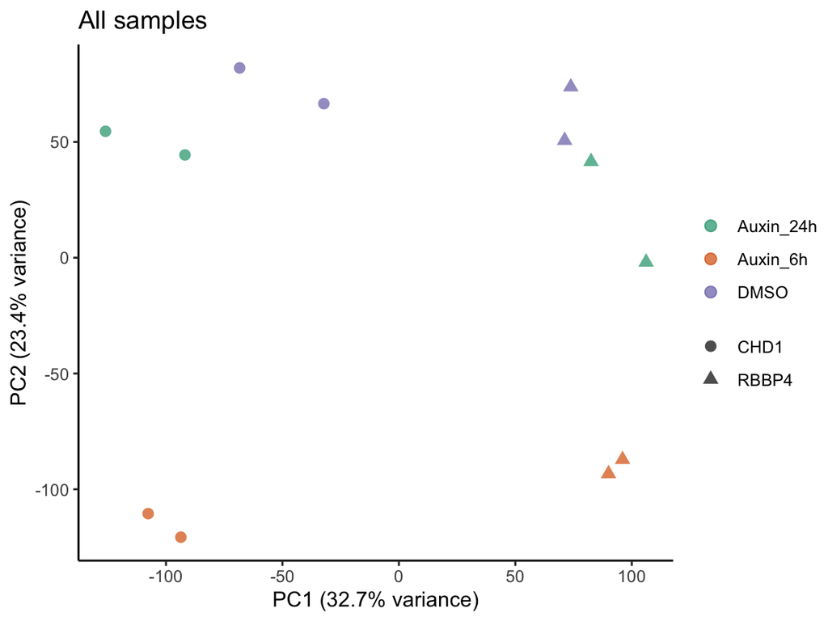

```r
PC_df = data.frame(pc_scores)
PC_df = cbind(PC_df, meta)

gPC = ggplot(PC_df, aes(x = PC1, y = PC2, shape=ko_gene, color=treatment)) +
  geom_point(size=2.5, alpha=0.7) + scale_color_brewer(palette = "Dark2") +
  labs(color="treatment", shape ="ko_gene") +
  xlab(sprintf("PC1 (%.1f%% variance)", pvs[1])) +
  ylab(sprintf("PC2 (%.1f%% variance)", pvs[2])) +
  ggtitle("All samples") +
  guides(
    color = guide_legend(title = NULL, order = 1),
    shape = guide_legend(title = NULL, order = 2)
  ) +
  theme(
    legend.margin = margin(0, 0, 0, 0),
    legend.box.just = "left",
    legend.direction = "vertical"
  )

print(gPC)
```

## Analysis samples under different treatments

For the October 2024 release of NW_RNAseq_1, there are two genes and three treatments.

Use each knockout gene as a DE group.

Run analysis for each DE group separately.

The comparison is between each pair of two treatments.

For the output files, create two versions, one with direct information, one with padj set to NA for the genes when the number of 0 per test is >=2 (usually this cutoff is set to be 4, but given that all comparison in this dataset are 2 vs 2, the cutoff is changed to 2 for this dataset).

In more details, for both versions of the outputs, make it one file per treatment comparison per DE group (DE group here is the knockout gene).

The first version of the output files contains

```
gene id, gene symbol
```

and for each knockout strategy:

```
baseMean, log2FoldChange, lfcSE, stat, pvalue, padj
```

The second version of the output files contains

```
gene id, gene symbol, chr, strand, position
```

and for each knockout strategy:

```
log2FoldChange, pvalue, padj (set to be NA if the number of 0 per test >= 2),
```

In addition, save out a separate file of the sample size for each comparison. This needs to be by DE group.

### Prepare output directories for DE results

```r
release_name = "2024_10_NW_RNAseq_1"

output_dir = file.path("results", release_name)
raw_output_dir = file.path(output_dir, "raw")
processed_output_dir = file.path(output_dir, "processed")

if (!file.exists(raw_output_dir)){
  dir.create(raw_output_dir, recursive = TRUE)
}

if (!file.exists(processed_output_dir)){
  dir.create(processed_output_dir, recursive = TRUE)
}
```

### Run DE analysis for all pairs of treatments

The pairs to run comparison for:

```
Auxin_24h v.s. DMSO
Auxin_6h v.s. DMSO
Auxin_24h v.s. Auxin_6h
```

```r
df_size = NULL

all_pairs = list()
all_pairs[[1]] = c("DMSO", "Auxin_24h")
all_pairs[[2]] = c("DMSO", "Auxin_6h")
all_pairs[[3]] = c("Auxin_6h", "Auxin_24h")
all_pairs
```

```
## [[1]]
## [1] "DMSO"      "Auxin_24h"
##
## [[2]]
## [1] "DMSO"     "Auxin_6h"
##
## [[3]]
## [1] "Auxin_6h"  "Auxin_24h"
```

```r
genos = unique(meta$ko_gene)
genos = sort(genos)
genos
```

```
## [1] "CHD1"  "RBBP4"
```

```r
## Generate sample information matrix
cols2kp = c("ko_gene", "treatment", "treatment_condition")
sample_info = meta[,cols2kp]

dim(sample_info)
```

```
## [1] 12  3
```

```r
sample_info[1:2,]
```

```
##    ko_gene treatment treatment_condition
## 10    CHD1  Auxin_6h               Auxin
## 1    RBBP4      DMSO                DMSO
```

```r
table(sample_info$ko_gene, sample_info$treatment)
```

```
##
##         Auxin_24h Auxin_6h DMSO
##   CHD1          2        2    2
##   RBBP4         2        2    2
```

```
## [1] "CHD1"
## [1] "-----------------------------------"
## [1] "Knockout gene: CHD1"
## [1] "DE analysis group CHD1 DESeq2 results:"
## [1] "-----------------------------------"
## [1] "After filtering by gene expression q75, the number of genes reduces from 26756 to 25951"
## [1] "After filtering by nonzero expression in at least 4 samples, the number of genes reduces from 25951 to 23849"
## Time difference of 35.33068 secs
```

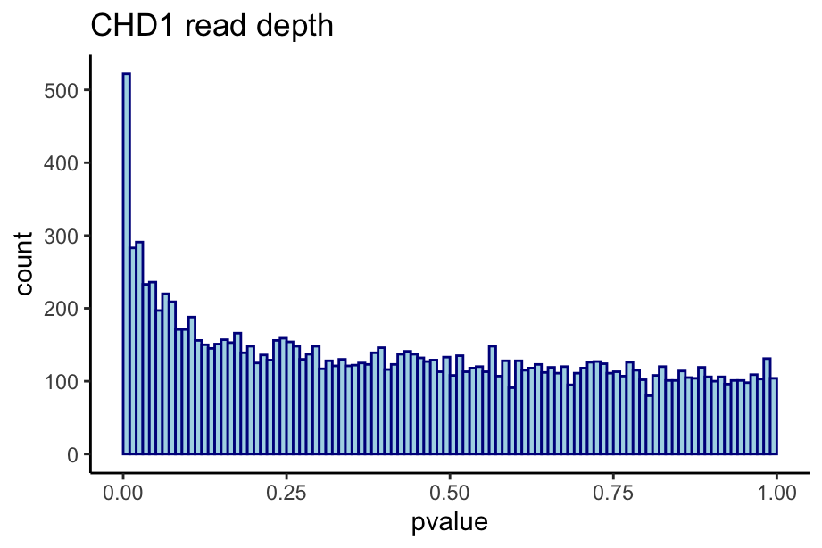

```
## [1] "prop of non-null for rd: 1.80e-01"
## [1] ""
## [1] "=========================================="
## [1] "Under knockout gene CHD1: Auxin_24h vs DMSO"
## [1] "=========================================="
## [1] ""
## [1] "Under knockout gene CHD1: Auxin_24h vs DMSO"
## [1] "number of DE genes: 313"
```

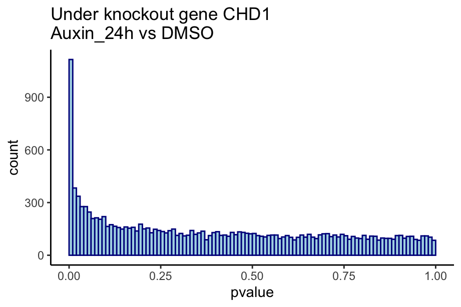

```
## [1] "hgnc_symbol empty string and NA tables:"
##
## FALSE  <NA>
## 19389  4460
##
## FALSE  TRUE
## 19389  4460
## [1] ""
## [1] "=========================================="
## [1] "Under knockout gene CHD1: Auxin_6h vs DMSO"
## [1] "=========================================="
## [1] ""
## [1] "Under knockout gene CHD1: Auxin_6h vs DMSO"
## [1] "number of DE genes: 3410"
```

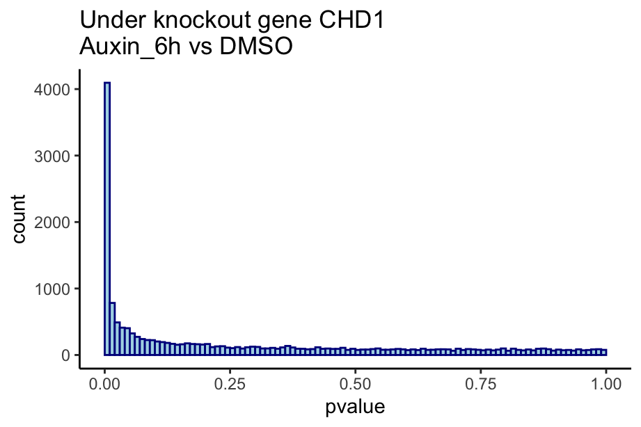

```
## [1] "hgnc_symbol empty string and NA tables:"
##
## FALSE  <NA>
## 19389  4460
##
## FALSE  TRUE
## 19389  4460
## [1] ""
## [1] "=========================================="
## [1] "Under knockout gene CHD1: Auxin_24h vs Auxin_6h"
## [1] "=========================================="
## [1] ""
## [1] "Under knockout gene CHD1: Auxin_24h vs Auxin_6h"
## [1] "number of DE genes: 2804"
```

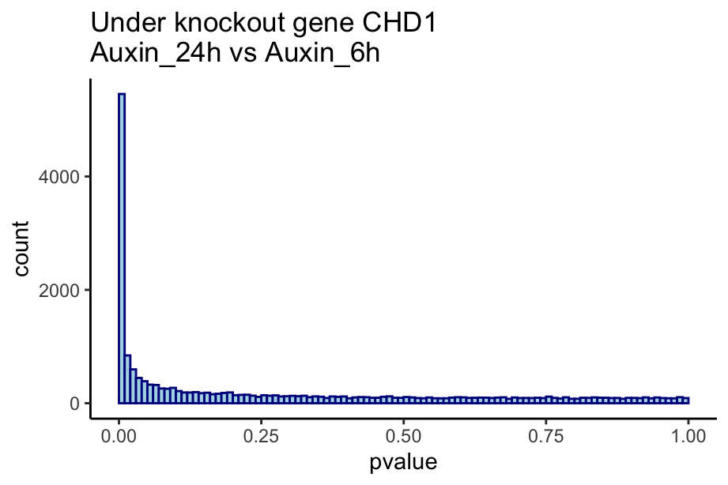

```
## [1] "hgnc_symbol empty string and NA tables:"
##
## FALSE  <NA>
## 19389  4460
##
## FALSE  TRUE
## 19389  4460
## [1] "RBBP4"
## [1] "-----------------------------------"
## [1] "Knockout gene: RBBP4"
## [1] "DE analysis group RBBP4 DESeq2 results:"
## [1] "-----------------------------------"
## [1] "After filtering by gene expression q75, the number of genes reduces from 26756 to 25895"
## [1] "After filtering by nonzero expression in at least 4 samples, the number of genes reduces from 25895 to 23587"
## Time difference of 19.56168 secs
```

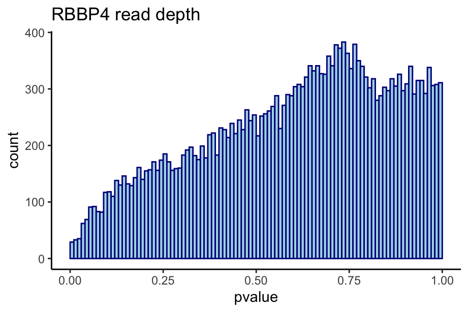

```
## [1] "prop of non-null for rd: 0.00e+00"
## [1] "rerun DESeq2 without read depth"
## Time difference of 4.17652 secs
## [1] ""
## [1] "=========================================="
## [1] "Under knockout gene RBBP4: Auxin_24h vs DMSO"
## [1] "=========================================="
## [1] ""
## [1] "Under knockout gene RBBP4: Auxin_24h vs DMSO"
## [1] "number of DE genes: 1594"
```

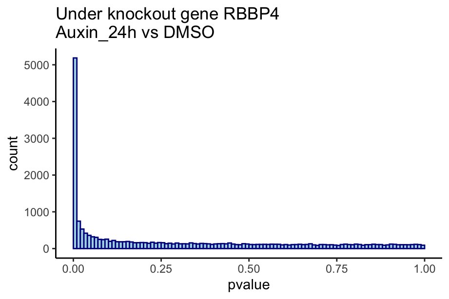

```
## [1] "hgnc_symbol empty string and NA tables:"
##
## FALSE  <NA>
## 19288  4299
##
## FALSE  TRUE
## 19288  4299
## [1] ""
## [1] "=========================================="
## [1] "Under knockout gene RBBP4: Auxin_6h vs DMSO"
## [1] "=========================================="
## [1] ""
## [1] "Under knockout gene RBBP4: Auxin_6h vs DMSO"
## [1] "number of DE genes: 3228"
```

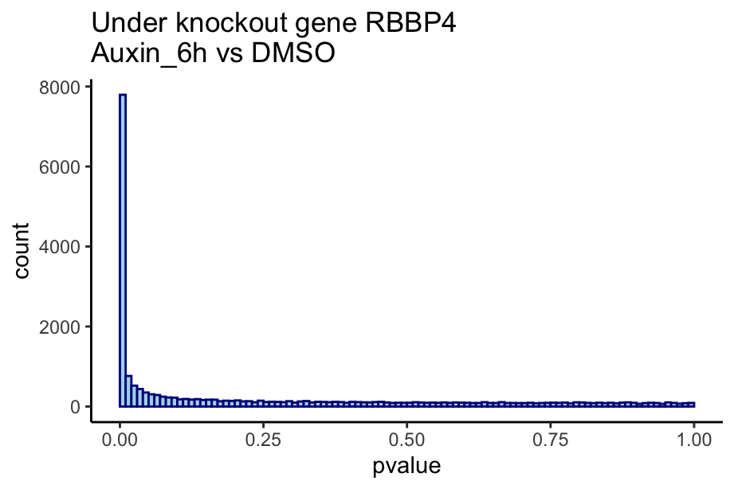

```
## [1] "hgnc_symbol empty string and NA tables:"
##
## FALSE  <NA>
## 19288  4299
##
## FALSE  TRUE
## 19288  4299
## [1] ""
## [1] "=========================================="
## [1] "Under knockout gene RBBP4: Auxin_24h vs Auxin_6h"
## [1] "=========================================="
## [1] ""
## [1] "Under knockout gene RBBP4: Auxin_24h vs Auxin_6h"
## [1] "number of DE genes: 2328"
```

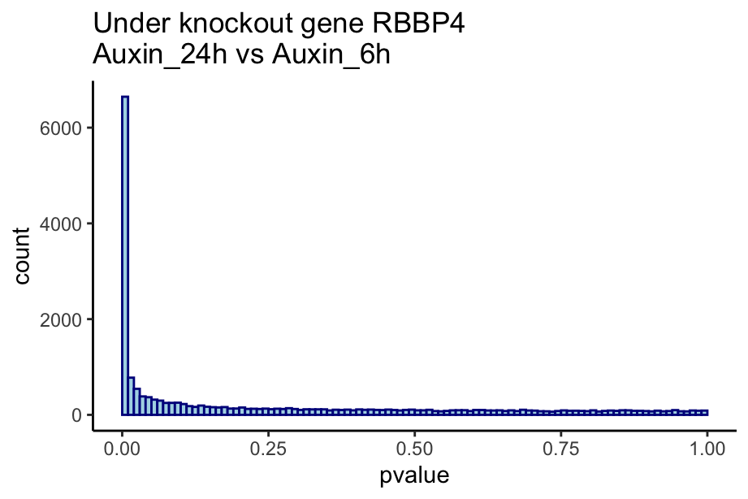

```
## [1] "hgnc_symbol empty string and NA tables:"
##
## FALSE  <NA>
## 19288  4299
##
## FALSE  TRUE
## 19288  4299
```

```r
for (geno in genos){

  print(geno)

  dg_index = which(sample_info$ko_gene==geno)
  cts_dat_m_dg = cts_dat[, dg_index]
  sample_info_dg = sample_info[dg_index, ]

  stopifnot(all(sample_info_dg$ko_gene==geno))

  print("-----------------------------------")
  print(paste0("Knockout gene: ", geno))
  print(sprintf("DE analysis group %s DESeq2 results:", geno))
  print("-----------------------------------")

  # do two steps of filtering
  # first, filter based on q75 of each gene
  # second, filter based on whether each gene is expressed in at least 4 samples

  dg_q75 = apply(cts_dat_m_dg, 1, quantile, probs=0.75)
  cts_dat_m_dg = cts_dat_m_dg[dg_q75 > 0,]

  print(sprintf("After filtering by gene expression q75, the number of genes reduces from %d to %d",
                length(dg_q75), nrow(cts_dat_m_dg)))

  n_pos = rowSums(cts_dat_m_dg>0)
  cts_dat_m_dg = cts_dat_m_dg[n_pos >= 4,]

  if (length(n_pos)==nrow(cts_dat_m_dg)){
    print("After filtering by nonzero expression in at least 4 samples, the number of genes does not change.")
  }else{
    print(sprintf("After filtering by nonzero expression in at least 4 samples, the number of genes reduces from %d to %d",
                  length(n_pos), nrow(cts_dat_m_dg)))
  }

  # update the q75 based on only genes used in the process
  sample_info_dg$q75 = apply(cts_dat_m_dg, 2, quantile, probs = 0.75)
  sample_info_dg$log_q75 = log(sample_info_dg$q75)


  dds = DESeqDataSetFromMatrix(cts_dat_m_dg, colData=sample_info_dg,
                                ~ treatment + log_q75)

  start.time <- Sys.time()
  dds = DESeq(dds)
  end.time <- Sys.time()

  time.taken <- end.time - start.time
  print(time.taken)

  ## association with read-depth
  res_rd = results(dds, name = "log_q75")
  res_rd = as.data.frame(res_rd)
  dim(res_rd)
  res_rd[1:2,]

  table(is.na(res_rd$padj))

  g0 = ggplot(res_rd %>% subset(!is.na(padj)), aes(x=pvalue)) +
    geom_histogram(color="darkblue", fill="lightblue",
                   breaks = seq(0,1,by=0.01)) +
    ggtitle(paste0(geno, " read depth"))
  print(g0)

  ## Rerun the analysis without read-depth if it is not significant for
  ## most genes, and the number of samples is small
  ## i.e., proportion of non-null in the distribution is smaller than 0.01
  ## (this needs to be restricted to the genes with not NA adjusted pvalue)
  ## or if smaller than 0.1 and the number of samples is not greater than 6

  pi_1_rd = max(0, mean(res_rd$pvalue[!is.na(res_rd$padj)] < 0.05) - 0.05)
  pi_1_rd = max(pi_1_rd, 0, 1 - 2*mean(res_rd$pvalue[!is.na(res_rd$padj)] > 0.5))

  print(sprintf("prop of non-null for rd: %.2e", pi_1_rd))

  if(pi_1_rd < 0.01 || (ncol(cts_dat_m_dg) <= 6 && pi_1_rd < 0.1 )){

    print("rerun DESeq2 without read depth")

    include_rd = 0

    dds = DESeqDataSetFromMatrix(cts_dat_m_dg, colData=sample_info_dg,
                                  ~ treatment)

    start.time <- Sys.time()
    dds = DESeq(dds)
    end.time <- Sys.time()

    time.taken <- end.time - start.time
    print(time.taken)

  }else{
    include_rd = 1
  }


  ## DE analysis for each pair of treatment
  table(sample_info_dg$treatment)

  for(pair_idx in 1:length(all_pairs)){

    control = all_pairs[[pair_idx]][1]
    case = all_pairs[[pair_idx]][2]

    compare_string = paste0(case, " vs ", control)

    print("")
    print("==========================================")
    print(paste0("Under knockout gene ", geno, ": ", compare_string))
    print("==========================================")
    print("")

    res_g1 = results(dds, contrast = c("treatment",
                                       case, control))
    res_g1 = signif(data.frame(res_g1), 3)

    # add a column to record the number of zeros per test
    test_index = which(sample_info_dg$treatment%in%c(case, control))

    cts_dat_m_dg_test = cts_dat_m_dg[, test_index]
    n_zero = rowSums(cts_dat_m_dg_test==0)
    res_g1$n_zeros = n_zero

    # record the number of samples involved in the comparison
    test_treatment_vec = sample_info_dg$treatment[test_index]

    df_size = rbind(df_size,
                    c(geno,
                      paste0(case, "_vs_", control),
                      sum(test_treatment_vec==case),
                      sum(test_treatment_vec==control)))

    # prepare a processed version of output
    res_g1_reduced = res_g1[, c("log2FoldChange", "pvalue", "padj", "n_zeros")]
    res_g1_reduced$padj[which(res_g1_reduced$n_zeros>=2)] = NA

    res_g1_reduced = res_g1_reduced[, c("log2FoldChange", "pvalue", "padj")]

    n_DE = sum(res_g1_reduced$padj < 0.05 & abs(res_g1_reduced$log2FoldChange) > log2(1.5),
               na.rm = TRUE)
    print(paste0("Under knockout gene ", geno, ": ", compare_string))
    print(sprintf("number of DE genes: %d", n_DE))

    g1 = ggplot(res_g1_reduced %>% subset(!is.na(padj)), aes(x=pvalue)) +
      geom_histogram(color="darkblue", fill="lightblue",
                     breaks = seq(0,1,by=0.01)) +
      ggtitle(paste0("Under knockout gene ", geno, "\n", compare_string))
    print(g1)

    tag1 = sprintf("%s_vs_%s_", case, control)
    colnames(res_g1) = paste0(tag1, colnames(res_g1))
    colnames(res_g1_reduced) = paste0(tag1, colnames(res_g1_reduced))


    res_df = data.frame(gene_ID=rownames(res_g1),
                        res_g1)
    dim(res_df)
    res_df[1:2,]


    res_reduced_gene_anno = gene_anno[match(rownames(res_g1_reduced),
                                            gene_anno$ensembl_gene_id), ]
    stopifnot(all(rownames(res_g1_reduced)==res_reduced_gene_anno$ensembl_gene_id))

    # set gene hgnc_symbol that equal "" to NA
    hgnc_symbol_vec = res_reduced_gene_anno$hgnc_symbol
    hgnc_symbol_vec[which(hgnc_symbol_vec=="")] = NA

    res_reduced_df = data.frame(gene_ID=rownames(res_g1_reduced),
                                hgnc_symbol=hgnc_symbol_vec,
                                chr=res_reduced_gene_anno$chr,
                                strand=res_reduced_gene_anno$strand,
                                start=res_reduced_gene_anno$start,
                                end=res_reduced_gene_anno$end,
                                res_g1_reduced)

    print("hgnc_symbol empty string and NA tables:")
    print(table(res_reduced_df$hgnc_symbol=="", useNA="ifany"))
    print(table(is.na(res_reduced_df$hgnc_symbol)))

    dim(res_reduced_df)
    res_reduced_df[1:2,]

    setting_name = paste0(case, "_vs_", control)

    fwrite(res_df,
           sprintf("%s/%s_%s_%s_DEseq2_raw.tsv",
                   raw_output_dir, release_name, geno, setting_name),
           sep="\t")
    fwrite(res_reduced_df,
           sprintf("%s/%s_%s_%s_DEseq2.tsv",
                   processed_output_dir, release_name, geno, setting_name),
           sep="\t")

  }

}
```

Save the size dataframe out

```r
colnames(df_size) = c("DE_group", "treatment_comparison",
                      "n_treatment_first", "n_treatment_second")
df_size = as.data.frame(df_size)

fwrite(df_size,
       sprintf("%s/%s_DE_n_samples.tsv", output_dir, release_name),
       sep="\t")
```

```r
gc()
```

```
##            used  (Mb) gc trigger  (Mb) limit (Mb) max used  (Mb)
## Ncells  7888448 421.3   12621332 674.1         NA 12621332 674.1
## Vcells 18805412 143.5   36645692 279.6      65536 36645692 279.6
```